# Universidad Nacional de Colombia

Diplomado Ciencia de datos

## Clusterización

En este caso práctico aplicaremos el algoritmos de clusterización para hacer agrupamiento de datos, aprenderemos cómo funcionan y cómo utilizarlos en un caso práctico

El caso estará estructurado así

1. Hacer un análisis exploratorio para revisar la estructura de los datos
2. Usar lo que observamos para guiar nuestro proceso de agrupamiento
3. Ajustar un algortimo de k-means a los datos disponibles
4. Ajustar un agrupamiento jerárquico
5. Hacer segmentaciones y conclusiones a partir del análisis

**Contexto:** Las competencias deportivas cada día recogen una gran cantidad de datos relacionados con el desempeño de sus equipos y jugadores para encontrar patrones en estos datos y tomar decisiones informadas basadas en ellos. De esta manera la competencia aumenta tanto dentro como fuera de la cancha.

**Problema de negocio:** Se tienen los datos de desempeño de los equipos de baloncesto del torneo NCAA March Madness que contiene las estadísticas de juego de 353 equipos de la liga. El objetivo es inspeccionar esta data utilizando técnicas de visualización y agrupación para encontrar patrones en el desempeño de los equipos y generar recomendaciones de umbrales en las estadísticas para que un equipo esté en el grupo de desempeño superior.

```r
# ruta directorio
setwd('C:/Users/Juliana/Desktop/Diplomado/D_2020/Casos/Casos/Clustering/R')
```

```r
# cargue librerias
library(ggplot2)
library(ggpubr)
library(ggcorrplot)
library(dplyr)
library(factoextra)
library(dbscan)
## Cargue de datos
datos <- read.csv('basketball_19.csv',header=T)
## nombres de las columnas
names(datos)
```

```
##  [1] "TEAM"       "CONF"       "G"          "W"          "ADJOE"
##  [6] "ADJDE"      "BARTHAG"    "EFG_O"      "EFG_D"      "TOR"
## [11] "TORD"       "ORB"        "DRB"        "FTR"        "FTRD"
## [16] "X2P_O"      "X2P_D"      "X3P_O"      "X3P_D"      "ADJ_T"
## [21] "WAB"        "POSTSEASON" "SEED"
```

```r
head(datos)
```

```
##             TEAM CONF  G  W ADJOE ADJDE BARTHAG EFG_O EFG_D  TOR TORD  ORB  DRB
## 1        Gonzaga  WCC 37 33 123.4  89.9  0.9744  59.0  44.2 14.9 19.0 31.5 26.8
## 2       Virginia  ACC 38 35 123.0  89.9  0.9736  55.2  44.7 14.7 17.5 30.4 25.4
## 3           Duke  ACC 38 32 118.9  89.2  0.9646  53.6  45.0 17.5 19.4 35.6 29.5
## 4 North Carolina  ACC 36 29 120.1  91.4  0.9582  52.9  48.9 17.2 18.3 35.3 22.8
## 5       Michigan  B10 37 30 114.6  85.6  0.9665  51.6  44.1 13.9 18.0 24.7 24.8
## 6   Michigan St.  B10 39 32 119.9  91.0  0.9597  55.2  43.9 18.5 14.9 33.9 26.4
##    FTR FTRD X2P_O X2P_D X3P_O X3P_D ADJ_T  WAB POSTSEASON SEED
## 1 35.3 25.9  61.4  43.4  36.3  30.4  72.0  7.0         E8    1
## 2 29.1 26.3  52.5  45.7  39.5  28.9  60.7 11.1  Champions    1
## 3 33.2 24.0  58.0  45.0  30.8  29.9  73.6 11.2         E8    1
## 4 30.2 28.4  52.1  47.9  36.2  33.5  76.0 10.0        S16    1
## 5 27.5 24.1  51.8  44.3  34.2  29.1  65.9  9.2        S16    2
## 6 33.6 27.5  54.3  41.9  37.8  31.6  68.6 10.7         F4    2
```

Estas son las variables que contiene el conjunto de datos

- TEAM: Equipo
- CONF: La conferencia en la que el equipo participa(A10 = Atlantic 10, ACC = Atlantic Coast Conference, AE = America East, Amer = American, ASun = ASUN, B10 = Big Ten, B12 = Big 12, BE = Big East, BSky = Big Sky, BSth = Big South, BW = Big West, CAA = Colonial Athletic Association, CUSA = Conference USA, Horz = Horizon League, Ivy = Ivy League, MAAC = Metro Atlantic Athletic Conference, MAC = Mid-American Conference, MEAC = Mid-Eastern Athletic Conference, MVC = Missouri Valley Conference, MWC = Mountain West, NEC = Northeast Conference, OVC = Ohio Valley Conference, P12 = Pac-12, Pat = Patriot League, SB = Sun Belt, SC = Southern Conference, SEC = South Eastern Conference, Slnd = Southland Conference, Sum = Summit League, SWAC = Southwestern Athletic Conference, WAC = Western Athletic Conference, WCC = West Coast Conference)
- G: Número de partidos jugados
- W: Número de partidos ganados
- ADJOE: Estimación de eficiencia ofensiva, puntos anotados por cada 100 posesiones
- ADJDE: Estimación de eficiencia defensiva, puntos permitidos por cada 100 posesiones del equipo contrario
- BARTHAG: Probabilidad de vencer a un equipo
- EFG_O: % tiros efectivos a favor
- EFG_D: % tiros efectivos en contra
- TOR: Porcentaje de rotación permitida (equipo pierde la posesión del balón contra el equipo contrario antes de que un jugador dispare a la canasta de su equipo)
- TORD: Porcentaje de rotación hecha al equipo contrario (se roba la pelota al contrincante)
- ORB: Porcentaje de rebote ofensivo
- B: Porcentaje de rebote defensivo
- FTR : Tasa de tiros libres hechos(que hace el equipo)
- FTRD: Tasa de tiros libres permitidos (que hace el contrincante)
- 2P_O: Porcentaje de tiros de 2 puntos hechos
- 2P_D: Porcentaje de tiros de 2 puntos permitidos
- 3P_O: Porcentaje de tiros de 3 puntos hechos
- 3P_D: Porcentaje de tiros de 3 puntos permitidos
- ADJ_T: Posesión del balón por 40 min
- WAB: Triunfos por encima de la ‘burbuja’ (la burbuja es el límite definido para pasar al campeonato NCAA March Madness Tournament
- POSTSEASON: Ronda en la que el equipo de fue eliminado (R68 = First Four, R64 = Round of 64, R32 = Round of 32, S16 = Sweet Sixteen, E8 = Elite Eight, F4 = Final Four, 2ND = Runner-up, Champion = Winner of the NCAA March Madness Tournament for that given year)
- SEED: Semilla definida por el torneo

## Exploración de los datos

```r
## dimension de los datos
ncol(datos)
```

```
## [1] 23
```

```r
nrow(datos)
```

```
## [1] 353
```

```r
## resumen de los datos
summary(datos)
```

```
##                 TEAM          CONF           G               W
##  Abilene Christian:  1   ACC    : 15   Min.   :26.00   Min.   : 3.00
##  Air Force        :  1   A10    : 14   1st Qu.:30.00   1st Qu.:12.00
##  Akron            :  1   B10    : 14   Median :31.00   Median :17.00
##  Alabama          :  1   CUSA   : 14   Mean   :31.75   Mean   :17.11
##  Alabama A&M      :  1   SEC    : 14   3rd Qu.:33.00   3rd Qu.:21.00
##  Alabama St.      :  1   Slnd   : 13   Max.   :39.00   Max.   :35.00
##  (Other)          :347   (Other):269
##      ADJOE           ADJDE          BARTHAG           EFG_O
##  Min.   : 83.7   Min.   : 85.2   Min.   :0.0346   Min.   :40.0
##  1st Qu.: 98.6   1st Qu.: 98.7   1st Qu.:0.2814   1st Qu.:48.8
##  Median :103.1   Median :104.0   Median :0.4762   Median :50.5
##  Mean   :103.3   Mean   :103.3   Mean   :0.4932   Mean   :50.6
##  3rd Qu.:107.7   3rd Qu.:107.8   3rd Qu.:0.6893   3rd Qu.:52.8
##  Max.   :123.4   Max.   :119.2   Max.   :0.9744   Max.   :59.0
##
##      EFG_D            TOR             TORD            ORB
##  Min.   :42.50   Min.   :13.50   Min.   :13.30   Min.   :15.90
##  1st Qu.:48.90   1st Qu.:17.20   1st Qu.:17.10   1st Qu.:25.40
##  Median :50.90   Median :18.50   Median :18.30   Median :28.30
##  Mean   :50.77   Mean   :18.61   Mean   :18.52   Mean   :28.25
##  3rd Qu.:52.60   3rd Qu.:19.80   3rd Qu.:19.80   3rd Qu.:31.00
##  Max.   :59.30   Max.   :25.10   Max.   :24.70   Max.   :38.70
##
##       DRB             FTR             FTRD          X2P_O           X2P_D
##  Min.   :21.70   Min.   :21.90   Min.   :21.8   Min.   :37.70   Min.   :40.70
##  1st Qu.:26.30   1st Qu.:29.90   1st Qu.:29.7   1st Qu.:47.70   1st Qu.:48.30
##  Median :28.30   Median :33.30   Median :32.7   Median :50.30   Median :50.20
##  Mean   :28.42   Mean   :32.95   Mean   :33.2   Mean   :50.06   Mean   :50.23
##  3rd Qu.:30.40   3rd Qu.:35.90   3rd Qu.:36.4   3rd Qu.:52.20   3rd Qu.:52.20
##  Max.   :37.10   Max.   :48.10   Max.   :54.0   Max.   :61.40   Max.   :61.20
##
##      X3P_O           X3P_D           ADJ_T            WAB
##  Min.   :27.90   Min.   :27.90   Min.   :60.70   Min.   :-23.400
##  1st Qu.:32.40   1st Qu.:32.90   1st Qu.:67.30   1st Qu.:-13.100
##  Median :34.20   Median :34.40   Median :69.00   Median : -8.600
##  Mean   :34.29   Mean   :34.42   Mean   :69.17   Mean   : -7.784
##  3rd Qu.:36.00   3rd Qu.:35.90   3rd Qu.:70.80   3rd Qu.: -3.100
##  Max.   :42.40   Max.   :41.80   Max.   :79.10   Max.   : 11.200
##
##    POSTSEASON       SEED
##  R64    : 32   Min.   : 1.000
##  R32    : 16   1st Qu.: 5.000
##  S16    :  8   Median : 9.000
##  E8     :  4   Mean   : 8.794
##  R68    :  4   3rd Qu.:13.000
##  (Other):  4   Max.   :16.000
##  NA's   :285   NA's   :285
```

Visualicemos el comportamiento de algunas variables

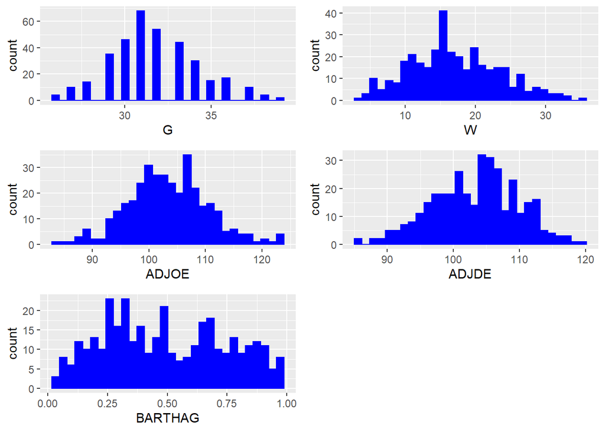

```r
## visualización de algunas variables
p1 <- ggplot(datos, aes(x=G)) + geom_histogram(color="blue", fill="blue")
p2 <- ggplot(datos, aes(x=W)) + geom_histogram(color="blue", fill="blue")
p3 <- ggplot(datos, aes(x=ADJOE)) + geom_histogram(color="blue", fill="blue")
p4 <- ggplot(datos, aes(x=ADJDE)) + geom_histogram(color="blue", fill="blue")
p5 <- ggplot(datos, aes(x=BARTHAG)) + geom_histogram(color="blue", fill="blue")


ggarrange(p1, p2, p3,p4, p5,ncol = 2, nrow = 3)
```

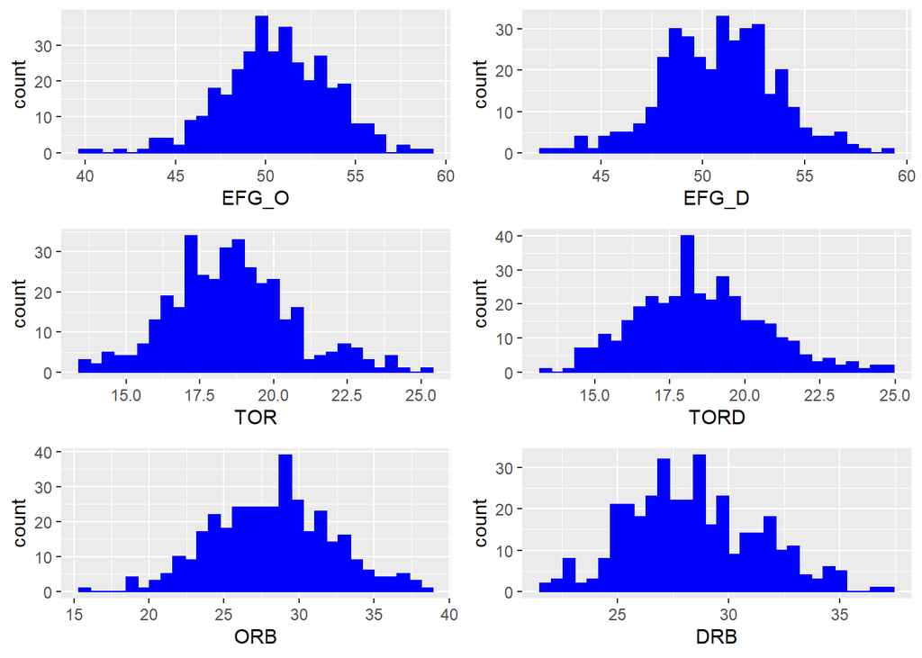

```r
p1 <- ggplot(datos, aes(x=EFG_O)) + geom_histogram(color="blue", fill="blue")
p2 <- ggplot(datos, aes(x=EFG_D)) + geom_histogram(color="blue", fill="blue")
p3 <- ggplot(datos, aes(x=TOR)) + geom_histogram(color="blue", fill="blue")
p4 <- ggplot(datos, aes(x=TORD)) + geom_histogram(color="blue", fill="blue")
p5 <- ggplot(datos, aes(x=ORB)) + geom_histogram(color="blue", fill="blue")
p6 <- ggplot(datos, aes(x=DRB)) + geom_histogram(color="blue", fill="blue")

ggarrange(p1, p2, p3,p4, p5,p6,
          ncol = 2, nrow = 3)
```

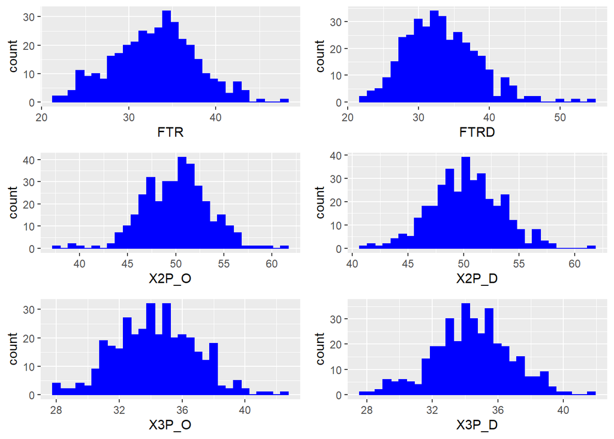

```r
p1 <- ggplot(datos, aes(x=FTR)) + geom_histogram(color="blue", fill="blue")
p2 <- ggplot(datos, aes(x=FTRD)) + geom_histogram(color="blue", fill="blue")
p3 <- ggplot(datos, aes(x=X2P_O)) + geom_histogram(color="blue", fill="blue")
p4 <- ggplot(datos, aes(x=X2P_D)) + geom_histogram(color="blue", fill="blue")
p5 <- ggplot(datos, aes(x=X3P_O)) + geom_histogram(color="blue", fill="blue")
p6 <- ggplot(datos, aes(x=X3P_D)) + geom_histogram(color="blue", fill="blue")

ggarrange(p1, p2, p3,p4, p5,p6,
          ncol = 2, nrow = 3)
```

Podríamos empezar a identificar cuál es el comportamiento de los equipos durante la temporada

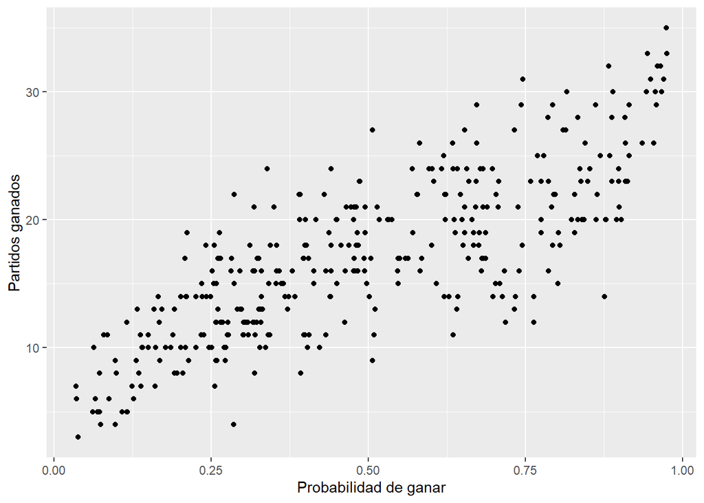

```r
# partidos ganados vs prob de vencer equipo
ggplot(datos, aes(x=BARTHAG, y=W)) + geom_point() +labs(x = "Probabilidad de ganar",y='Partidos ganados')
```

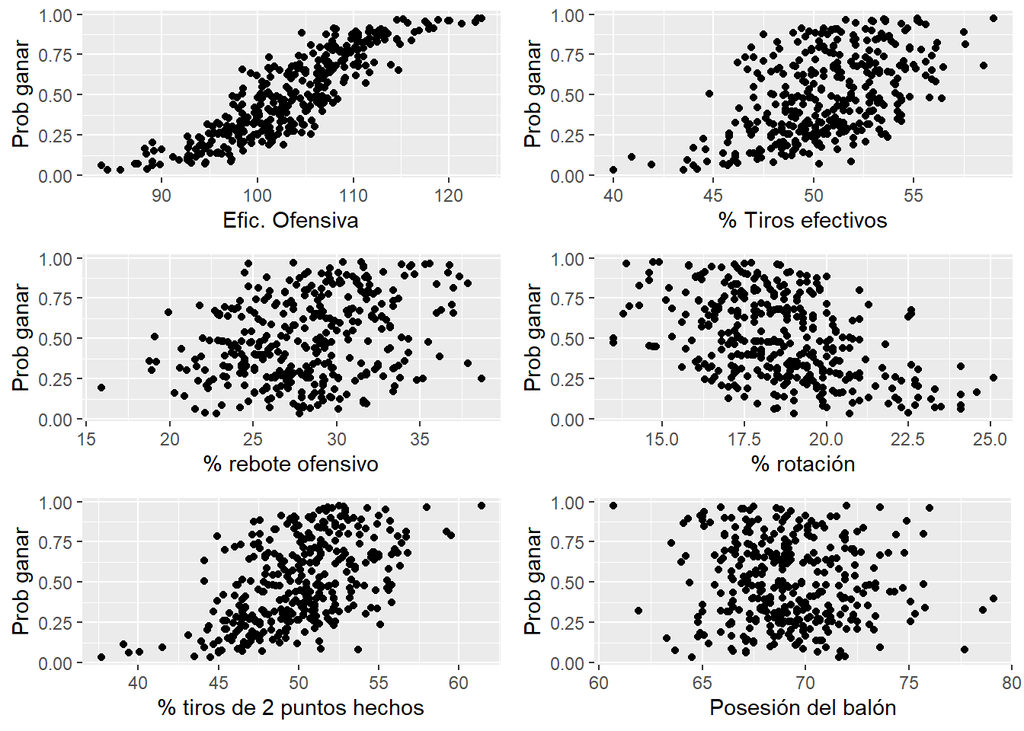

```r
# relacion de probabilidad de ganar con otras variables
p1 <- ggplot(datos, aes(x=ADJOE, y=BARTHAG)) + geom_point() +labs(x = "Efic. Ofensiva",y='Prob ganar')
p2 <- ggplot(datos, aes(x=EFG_O, y=BARTHAG)) + geom_point() +labs(x = "% Tiros efectivos",y='Prob ganar')
p3 <- ggplot(datos, aes(x=ORB, y=BARTHAG)) + geom_point() +labs(x = "% rebote ofensivo",y='Prob ganar')
p4 <- ggplot(datos, aes(x=TOR, y=BARTHAG)) + geom_point() +labs(x = "% rotación",y='Prob ganar')
p5 <- ggplot(datos, aes(x=X2P_O, y=BARTHAG)) + geom_point() +labs(x = "% tiros de 2 puntos hechos",y='Prob ganar')
p6 <- ggplot(datos, aes(x=ADJ_T, y=BARTHAG)) + geom_point() +labs(x = "Posesión del balón",y='Prob ganar')

ggarrange(p1, p2, p3,p4, p5,p6,
          ncol = 2, nrow = 3)
```

Inspeccionemos las correlaciones existentes entre las variables numéricas

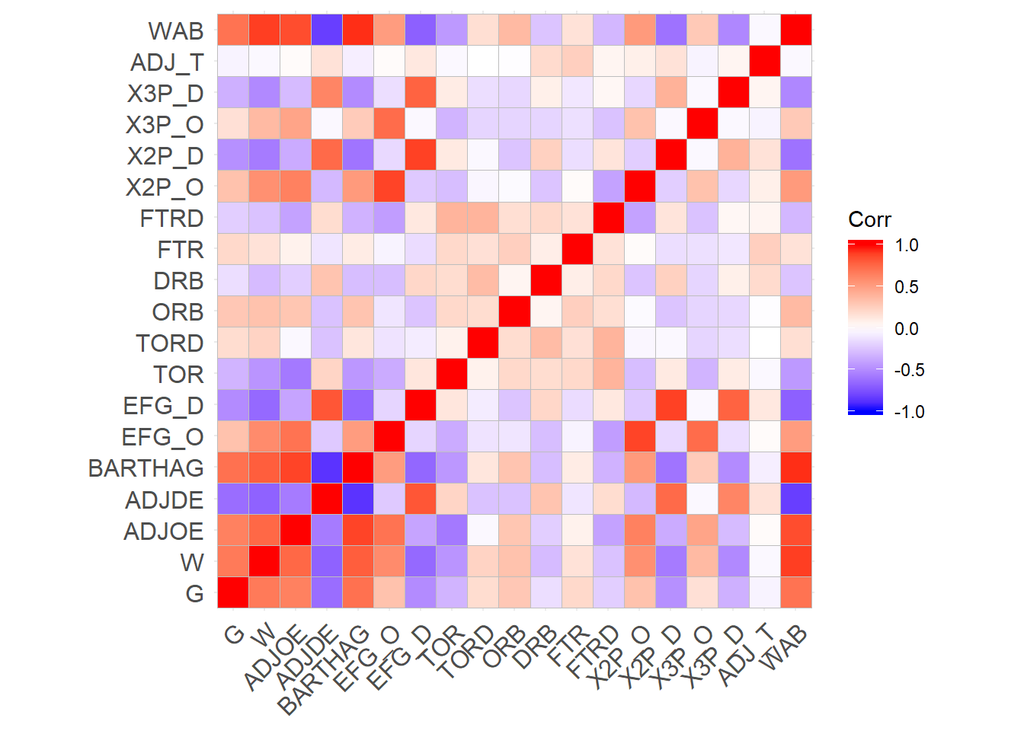

```r
# selección variables numéricas
km_data <- subset(datos, select = -c(TEAM,CONF,POSTSEASON,SEED) )
# matriz de correlacion
ggcorrplot(round(cor(km_data),2))
```

## Agrupamiento

A partir del análisis exploratorio, escogemos algunas variables que parecen tener una mayor variabilidad y nos permitirán identificar tipos de equipos

```r
# selección variables de interés
km <- km_data[,c('W','ADJOE','BARTHAG','EFG_O','X2P_O','WAB')]
head(km)
```

```
##    W ADJOE BARTHAG EFG_O X2P_O  WAB
## 1 33 123.4  0.9744  59.0  61.4  7.0
## 2 35 123.0  0.9736  55.2  52.5 11.1
## 3 32 118.9  0.9646  53.6  58.0 11.2
## 4 29 120.1  0.9582  52.9  52.1 10.0
## 5 30 114.6  0.9665  51.6  51.8  9.2
## 6 32 119.9  0.9597  55.2  54.3 10.7
```

Al igual que en ACP es importante estandarizar las variables que vamos a utilizar. La función scale nos permite hacerlo en una sola linea

```r
# estandarizar variables
km_scale <-scale(km)
head(km_scale)
```

```
##          W    ADJOE  BARTHAG     EFG_O     X2P_O      WAB
## 1 2.492032 2.858115 1.901878 2.8581869 3.3721723 2.076184
## 2 2.805758 2.801135 1.898716 1.5650667 0.7255688 2.651982
## 3 2.335169 2.217091 1.863144 1.0205951 2.3611103 2.666026
## 4 1.864580 2.388031 1.837848 0.7823888 0.6066204 2.497499
## 5 2.021443 1.604557 1.870653 0.3400056 0.5174090 2.385149
## 6 2.335169 2.359541 1.843777 1.5650667 1.2608369 2.595806
```

## Agrupamiento k-means

En R utilizamos la función **kmeans**. Los principales argumentos que debemos dar a la función son:

- x: una matriz numérica de los datos
- centers: el número de clusters

Dado que el algortimo de kmeans puede dar resultados diferentes cada vez que lo corramos, es necesario fijar una semilla con la función set.seed(). De esta manera nuestros resultados pueden ser reproducibles.

```r
### k-means
set.seed(42)
kmeans <- kmeans(km_scale, centers = 3)
```

Los principales atributos generados por el algoritmo son:

- cluster: vector de clusters asignados a las observaciones
- centers: centroides
- totss: Suma de cuadrados totales
- tot.withinss: Total Suma de cuadrados dentro (inercia)

```r
# resultados
names(kmeans)
```

```
## [1] "cluster"      "centers"      "totss"        "withinss"     "tot.withinss"
## [6] "betweenss"    "size"         "iter"         "ifault"
```

La suma de distancias cuadradas de cada punto a su centroide en esta solución es de

```r
# inercia o suma de cuadrados dentro total
kmeans$tot.withinss
```

```
## [1] 802.6093
```

Pero este número por si solo no es muy explicativo

**Centroides**

Tener en cuenta que las variables están estandarizadas, no necesariamente estos valores tengan un significado explícito pero sus magnitudes y sentidos si nos pueden decir mucho sobre las variables originales

```r
# centroides
kmeans$centers
```

```
##             W       ADJOE     BARTHAG       EFG_O       X2P_O        WAB
## 1  1.12231136  1.12536811  1.19418871  0.85956902  0.84635671  1.2396330
## 2 -1.04002760 -1.13575994 -1.14416431 -1.05099710 -1.05097337 -1.0786352
## 3 -0.09761525 -0.04837169 -0.08386635  0.06084159  0.06850317 -0.1451848
```

Guardamos la asignación del cluster en una nueva columna del data set

```r
# etiquetas de clusters
datos$cluster <- kmeans$cluster
```

Y podemos visualizar cómo se comportan los clusters con respecto a las variables originales

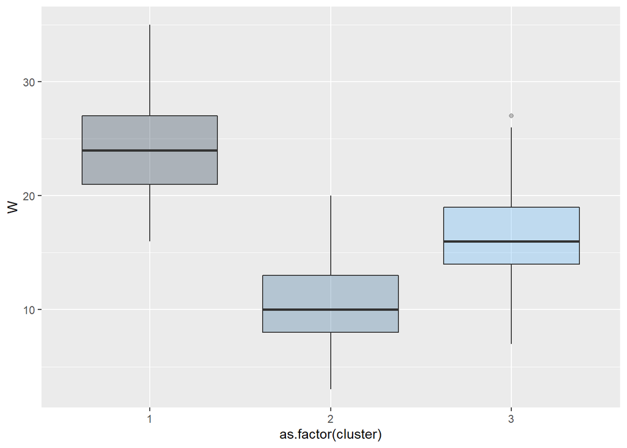

```r
## exploración de clusters
ggplot(datos, aes(x=as.factor(cluster), y=W, fill=cluster)) +
  geom_boxplot(alpha=0.3) +
  theme(legend.position="none")
```

```r
# resumen variables por cluster

datos %>%
  group_by(cluster) %>%
  summarise_at(vars('W','ADJOE','BARTHAG','EFG_O','X2P_O','WAB'), mean)
```

```
## # A tibble: 3 x 7
##   cluster     W ADJOE BARTHAG EFG_O X2P_O    WAB
##     <int> <dbl> <dbl>   <dbl> <dbl> <dbl>  <dbl>
## 1       1  24.3 111.    0.795  53.1  52.9   1.04
## 2       2  10.5  95.4   0.204  47.5  46.5 -15.5
## 3       3  16.5 103.    0.472  50.8  50.3  -8.82
```

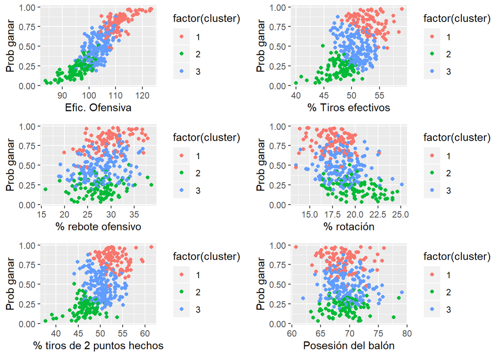

```r
# relacion de probabilidad de ganar con otras variables
p1 <- ggplot(datos, aes(x=ADJOE, y=BARTHAG)) + geom_point(aes(color = factor(cluster))) +labs(x = "Efic. Ofensiva",y='Prob ganar')
p2 <- ggplot(datos, aes(x=EFG_O, y=BARTHAG)) + geom_point(aes(color = factor(cluster))) +labs(x = "% Tiros efectivos",y='Prob ganar')
p3 <- ggplot(datos, aes(x=ORB, y=BARTHAG)) + geom_point(aes(color = factor(cluster))) +labs(x = "% rebote ofensivo",y='Prob ganar')
p4 <- ggplot(datos, aes(x=TOR, y=BARTHAG)) + geom_point(aes(color = factor(cluster))) +labs(x = "% rotación",y='Prob ganar')
p5 <- ggplot(datos, aes(x=X2P_O, y=BARTHAG)) + geom_point(aes(color = factor(cluster))) +labs(x = "% tiros de 2 puntos hechos",y='Prob ganar')
p6 <- ggplot(datos, aes(x=ADJ_T, y=BARTHAG)) + geom_point(aes(color = factor(cluster))) +labs(x = "Posesión del balón",y='Prob ganar')

ggarrange(p1, p2, p3,p4, p5,p6,
          ncol = 2, nrow = 3)
```

## Agrupamiento Jerárquico

En el agrupamiento jerárquico primero podemos inspeccionar cuántos clusters debería considerar el algoritmo usando el dendograma.

Para utilizar la función **hclust** en R se requiere tener una matriz de distancia como insumo

```r
# matriz de distancias
mat_dist <- dist(km_scale, method='euclidean') # la función hclust necesita como insumo una matriz de distancias
```

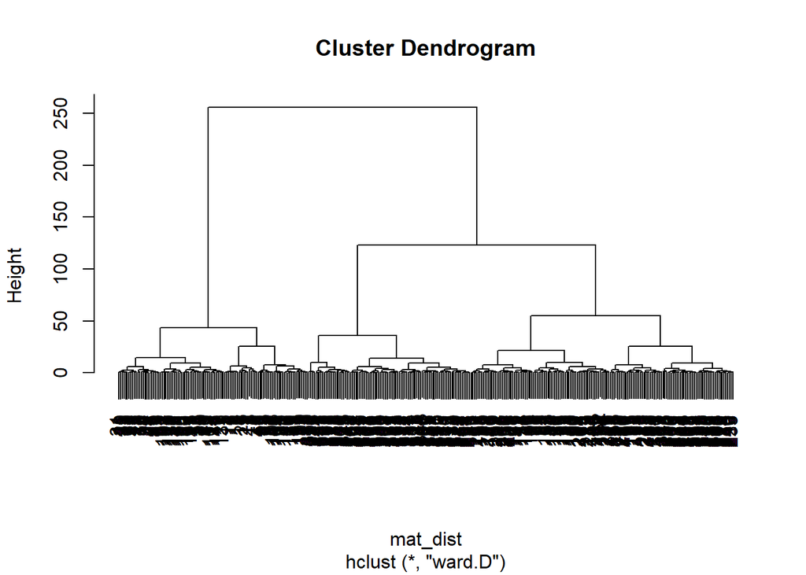

```r
# dendograma
dend <- hclust(mat_dist,method='ward.D')
plot(dend)
```

El gráfico nos muestra las ramificaciones de posibles clusters y nos puede indicar un buen número de clusters. Para continuar con la lógica del k-means anterior utilizaremos el agrupamiento de 3 clusters

```r
# clustering
jer <- cutree(dend,k=3)
```

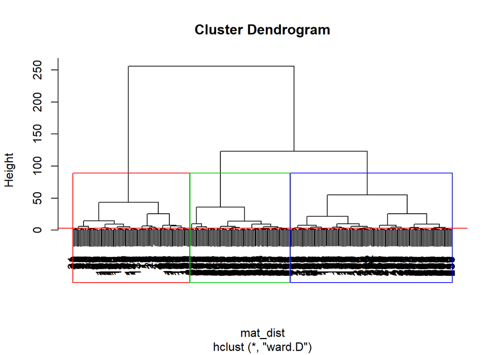

```r
plot(dend)
rect.hclust(dend , k = 3, border = 2:6)
abline(h = 3, col = 'red')
```

Guardemos el cluster asignado a cada observación

```r
# guardar etiqueta de cluster
datos$cluster_j <- jer
```

Comparemos los resultados del k-means con el jerárquico.

**Nota:** Los algoritmos no necesariamente van a dar las mismas etiquetas a cada observación, esto incluso si se corre el mismo k-means varias veces los resultados pueden ser diferentes. Lo que queremos es analizar que tan similar es la asignación de clusters

```r
# cruce de clusters
table(datos$cluster,datos$cluster_j)
```

```
##
##       1   2   3
##   1  93   4   0
##   2   0   4  85
##   3  16 143   8
```

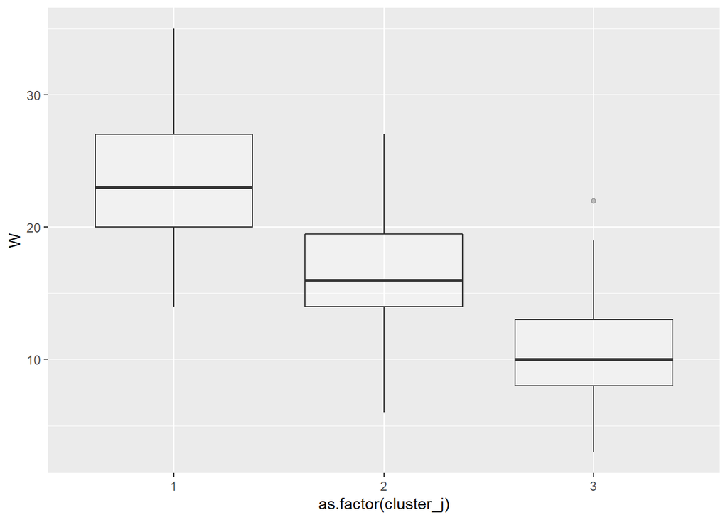

```r
## exploración de clusters
ggplot(datos, aes(x=as.factor(cluster_j), y=W, fill=cluster)) +
  geom_boxplot(alpha=0.3) +
  theme(legend.position="none")
```

```r
# resumen variables por cluster

datos %>%
  group_by(cluster_j) %>%
  summarise_at(vars('W','ADJOE','BARTHAG','EFG_O','X2P_O','WAB'), mean)
```

```
## # A tibble: 3 x 7
##   cluster_j     W ADJOE BARTHAG EFG_O X2P_O     WAB
##       <int> <dbl> <dbl>   <dbl> <dbl> <dbl>   <dbl>
## 1         1  23.5 111.    0.782  52.9  52.5   0.247
## 2         2  16.5 103.    0.462  50.7  50.3  -8.86
## 3         3  10.6  95.7   0.206  47.7  46.7 -15.5
```

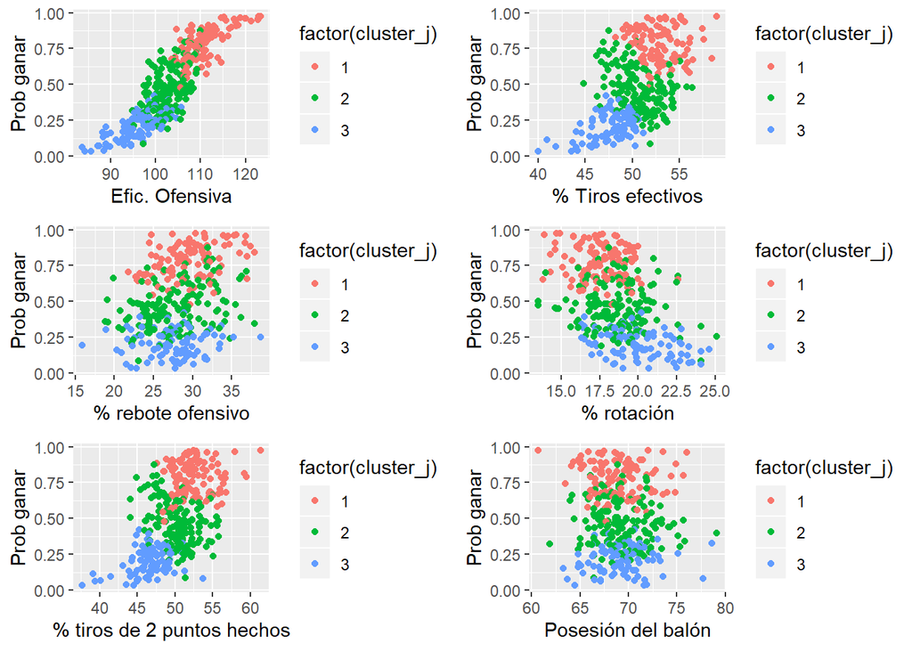

```r
# relacion de probabilidad de ganar con otras variables
p1 <- ggplot(datos, aes(x=ADJOE, y=BARTHAG)) + geom_point(aes(color = factor(cluster_j))) +labs(x = "Efic. Ofensiva",y='Prob ganar')
p2 <- ggplot(datos, aes(x=EFG_O, y=BARTHAG)) + geom_point(aes(color = factor(cluster_j))) +labs(x = "% Tiros efectivos",y='Prob ganar')
p3 <- ggplot(datos, aes(x=ORB, y=BARTHAG)) + geom_point(aes(color = factor(cluster_j))) +labs(x = "% rebote ofensivo",y='Prob ganar')
p4 <- ggplot(datos, aes(x=TOR, y=BARTHAG)) + geom_point(aes(color = factor(cluster_j))) +labs(x = "% rotación",y='Prob ganar')
p5 <- ggplot(datos, aes(x=X2P_O, y=BARTHAG)) + geom_point(aes(color = factor(cluster_j))) +labs(x = "% tiros de 2 puntos hechos",y='Prob ganar')
p6 <- ggplot(datos, aes(x=ADJ_T, y=BARTHAG)) + geom_point(aes(color = factor(cluster_j))) +labs(x = "Posesión del balón",y='Prob ganar')

ggarrange(p1, p2, p3,p4, p5,p6,
          ncol = 2, nrow = 3)
```

## DBSCAN

Ajustamos también un DBSCAN a nuestros datos

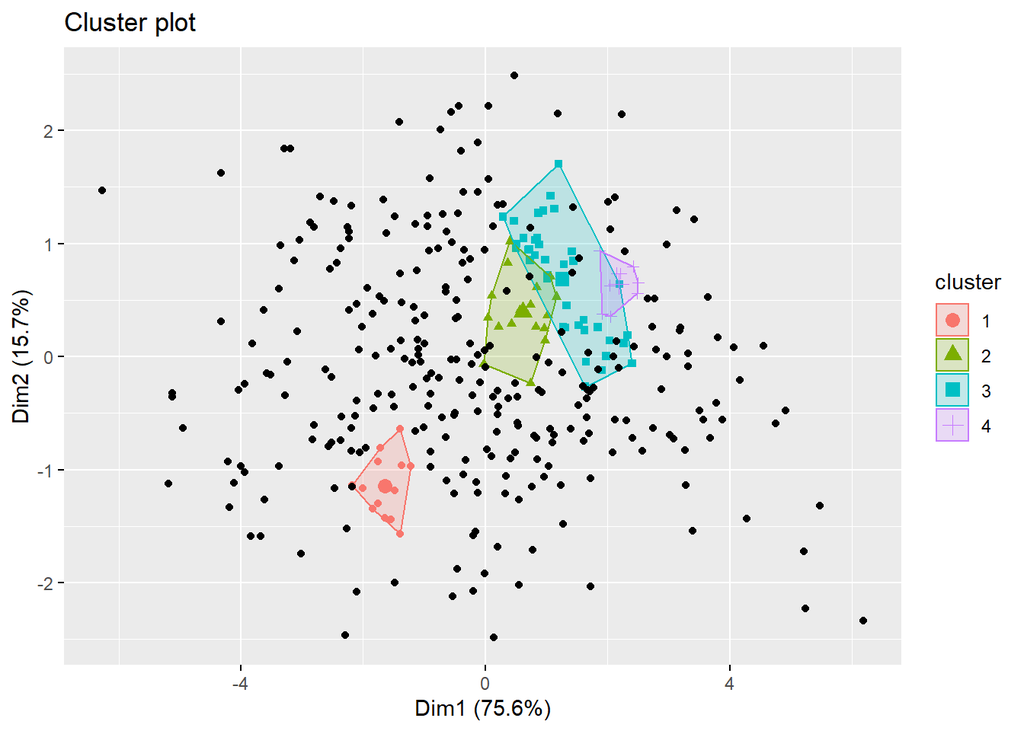

```r
cl<-dbscan(km_scale,eps=0.70,minPts = 10)
datos$cluster_den <- cl$cluster
fviz_cluster(cl, km_scale, stand = FALSE, ellipse = TRUE, geom = "point")
```

```r
table(datos$cluster_den)
```

```
##
##   0   1   2   3   4
## 275  13  17  39   9
```

En este caso particular DBSCAN no parece ser una buena solución. Sólo identifica 4 clusters pero la gran mayoría de puntos quedan identificados como noise points

## Ejercicios

1. Analizando los clusters formados por el k-means ¿Qué nombres le podríamos asignar a cada uno de los clusters que identifiquen sus comportamientos?
2. ¿Podríamos utilizar estos nombres para los resultados del jerárquico?
3. En el dendograma del agrupamiento jerárquico vimos que 5 clusters podría ser una solución. Ajustemos tanto para k-means como para el jerárquico nuevos agrupamientos utilizando 5 clusters. ¿Qué podemos concluir? ¿Cuál sería la mejor solución?

## Conclusiones

- Efectivamente se logran diferenciar tres grandes segmentos en los equipos caracterizados por su desempeño
- Se pueden identificar patrones en las métricas que permitan definir umbrales mínimos para los indicadores de rendimiento
- Se requiere de mayor información para escoger el número de clusters (más adelante lo veremos)